# Sensor Signal Analysis for Predicting Semiconductor Manufacturing Defects

Using PCA here may not be advisable, as the data is sparse. We attempt feature selection instead.

```r
glimpse(numeric_data$Label)
```

[output not shown]

```r
unique(numeric_data$Label)
```

[output not shown]

```r
numeric_data <- numeric_data %>%
  mutate(Label = factor(Label, levels = c(-1, 1), labels = c("neg", "pos")))
```

```r
#glimpse(numeric_data)
```

Next we’ll perform feature reduction with a Lasso model.

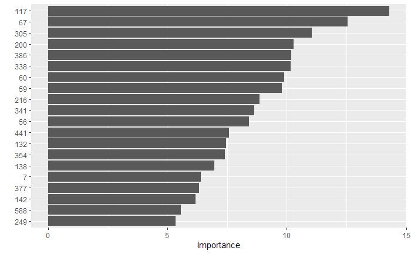

```r
set.seed(123)
folds <- vfold_cv(numeric_data, v = 10)

# Recipe using numeric_data (not train_data)
rec <- recipe(Label ~ ., data = numeric_data) %>%
  step_dummy(all_nominal_predictors()) %>%
  step_zv(all_predictors()) %>%
  step_normalize(all_numeric_predictors())

mod <- logistic_reg(penalty = tune(), mixture = 1) %>%
  set_engine("glmnet") %>%
  set_mode("classification")

wf <- workflow() %>%
  add_recipe(rec) %>%
  add_model(mod)

penalty_grid <- grid_regular(
  penalty(range = c(-4, 0)),
  levels = 10
)

set.seed(123)
res <- tune_grid(
  wf,
  resamples = folds,
  grid = penalty_grid,
  metrics = metric_set(roc_auc)
)

best_penalty <- select_best(res, metric = "roc_auc")

final_wf <- finalize_workflow(wf, best_penalty)

# Fit final workflow to numeric_data
final_fit <- fit(final_wf, data = numeric_data)

vip(final_fit$fit$fit$fit, num_features = 20)
```

Now that we have our reduced variables. Let’s check that our assumptions for logistic regression are met. We know that our assumptions are Linearity of log-odds, no multiconiliearity, no overdispersion, no influential outliers, good model fit.

Here’s our check for overdispersion.

```r
# Extract fitted model
model <- final_fit$fit$fit$fit  # glm object

# Calculate dispersion statistic
dispersion <- sum(residuals(model, type = "pearson")^2) / model$df.residual
dispersion
```

```
numeric(0)
```

Next, we run a logistic regression with those variables.

```r
# Suppose your top predictors are in a character vector:
top_vars <- c("117", "67", "305", "200", "386", "338", "60", "59", "216", "341", "56", "441", "132", "354", "138", "7", "377", "142", "588", "249")

# Subset your data (plus Label)
reduced_data <- numeric_data %>%
  select(all_of(c("Label", top_vars)))
```

```r
# Make sure Label is binary (0/1)
reduced_data <- reduced_data %>%
  mutate(Label = as.numeric(as.factor(Label)) - 1)

# Get only numeric predictors (excluding Label)
numeric_vars <- numeric_data %>%
  select(-Label) %>%
  select(where(is.numeric)) %>%
  names()

# Create a long dataset for ggplot
logit_df <- numeric_data %>%
  pivot_longer(all_of(numeric_vars), names_to = "predictor", values_to = "value") %>%
  group_by(predictor, value) %>%
  summarise(prob = mean(Label), .groups = "drop") %>%
  mutate(logit = log(prob / (1 - prob))) %>%
  filter(is.finite(logit))  # remove infs and NaNs

# Plot smoothed logit for each predictor
ggplot(logit_df, aes(x = value, y = logit)) +
  geom_point(alpha = 0.4) +
  geom_smooth(method = "loess", se = FALSE, color = "blue") +
  facet_wrap(~ predictor, scales = "free_x") +
  theme_minimal() +
  labs(title = "Check for Linearity of the Log-Odds",
       y = "Log-Odds (logit)",
       x = "Predictor Value")
```

[output not shown]

```r
# New recipe
rec_reduced <- recipe(Label ~ ., data = reduced_data) %>%
  step_dummy(all_nominal_predictors()) %>%
  step_normalize(all_numeric_predictors())

# Logistic regression without penalty
log_reg <- logistic_reg() %>%
  set_engine("glm") %>%
  set_mode("classification")

# Workflow
wf_reduced <- workflow() %>%
  add_recipe(rec_reduced) %>%
  add_model(log_reg)

# Fit model
final_fit_reduced <- fit(wf_reduced, data = reduced_data)

# Summarize model coefficients
final_fit_reduced
```

[output not shown]

```r
glimpse(reduced_data)
```

[output not shown]

Response Variable: The final column in the dataset “Label” will be our binary outcome. Explanatory Variables: A subset of the 590 sensor features.

## Exploratory Data Plots

```r
# Convert label to factor if needed
secom$label <- as.factor(secom$label)

# Example: Distribution of the first sensor by outcome
ggplot(secom, aes(x = secom[[1]], fill = label)) +
  geom_density(alpha = 0.5) +
  labs(title = "Sensor 1 Density by Product Outcome", x = "Sensor 1 Reading", fill = "Label") +
  theme_classic()

ggplot(secom, aes(x = secom[[2]], fill = label)) +
  geom_density(alpha = 0.5) +
  labs(title = "Sensor 2 Density by Product Outcome", x = "Sensor 1 Reading", fill = "Label") +
  theme_classic()

ggplot(secom, aes(x = secom[[3]], fill = label)) +
  geom_density(alpha = 0.5) +
  labs(title = "Sensor 3 Density by Product Outcome", x = "Sensor 1 Reading", fill = "Label") +
  theme_classic()

ggplot(secom, aes(x = secom[[4]], fill = label)) +
  geom_density(alpha = 0.5) +
  labs(title = "Sensor 4 Density by Product Outcome", x = "Sensor 1 Reading", fill = "Label") +
  theme_classic()

ggplot(secom, aes(x = secom[[5]], fill = label)) +
  geom_density(alpha = 0.5) +
  labs(title = "Sensor 5 Density by Product Outcome", x = "Sensor 1 Reading", fill = "Label") +
  theme_classic()

# Example: Count of pass/fail
ggplot(secom, aes(x = label)) +
  geom_bar(fill = "steelblue") +
  labs(title = "Count of Pass vs Fail Products", x = "Outcome", y = "Count") +
  theme_classic()
```

[output not shown]

## Next Steps

Over the next week, I will: Handle missing data using appropriate imputation methods. Conduct feature selection to identify the most informative sensors. Fit a logistic regression model to the training data. Evaluate model performance using accuracy, ROC/AUC, and confusion matrix.

## References

UCI Machine Learning Repository. SECOM Data Set. https://archive.ics.uci.edu/ml/datasets/SECOM

James, G., Witten, D., Hastie, T., & Tibshirani, R. (2021). An Introduction to Statistical Learning with Applications in R (2nd ed.).